# IE-0217 Estructuras de datos y algoritmos para ingeniería

Proyecto: FLTK/C++ Uso de interfaz Visual en C++ con caso de uso Calculadora

Kenny Wu Wen C08592

III-2020 24/2/2021

## Introduccion

Se plantea crear una calculadora simple con las bibliotecas FLTK en el lenguaje de programacion C++.

### Objetivos

- Investigar sobre el uso de las librerías FLTK para desarrollo de aplicaciones visuales
- Investigar sobre el funcionamiento del algoritmo infix to postfix (Se va a utilizar la solucion dada por el profesor que se encuentra en la semana04, clase11, modulo17)
- Diseñar e implementar una interfaz de calculadora simple
- Investigar sobre el manejo de eventos con las librerias FLTK

## FLTK

[FLTK](https://www.fltk.org/doc-1.3/fltk.pdf) es software libre y sus siglas significan **F**ast **L**ight **T**ool **K**it y son unas bibliotecas desarrolladas por Bill Spitzak. Fue creada para el desarrollo de programacion con graficos 3D, por lo que cuenta con una interfaz OpenGL, sin embargo, es facil y simple de manejar y entender por lo que sirve para desarrollar aplicaciones generales. Además incluye a FLUID (del inglés, FLTK User Interface Designer), que facilita la creacion de las aplicaciones. Si lo comparamos con otras bibliotecas como Qt y wxWidgets, FLTK se centra mas en la eficiencia que en la apariencia y a causa de esto es mas usado para crear programas para utilidad que no se enfoquen en la apariencia sino en eficacia.

En resumen:

| Ventanas de FLTK | Desventajas de FLTK |
| --- | --- |
| Tamaño ligero en los programas | Pocos widgets |
| Consume bajos recursos | Menos efectos visuales |
| Es estaticamente enlazada, el enlace dinamico tambien | Apariencia pobre |
| Rapido aprendizaje |  |

Algunos programas que usan FLTK: CinePaint, flwm, Nuke, PosteRazor, Dillo, entre otros.

### Manejo de eventos de FLTK

#### 1.handle

Se usa para manejar eventos especificos cuando se interactua con el widget, es una funcion virtual, osea, se puede modificar para lo que uno desee que ocurra dependiendo de los eventos

```r
int Fl_Window::handle (int event ) [virtual]
```

##### Ejemplo de uso de handle por polimorfismo

###### Evento_Window.h

```r
#ifndef EVENTWINDOW_H
#define EVENTWINDOW_H
#include <FL/Fl_Window.H>
#include <FL/Fl.H>
#include <stdio.h>
class EventWindow: public Fl_Window
{
private:
    int handle_mouse(int event, int button, int x, int y);
    int handle_key(int event,int key);
public:
    EventWindow(int width, int height);
    int handle(int e);
};



#endif // EVENTWINDOW_H
```

###### Evento_Window.cpp

```r
#include "EventWindow.h"
char * foo;

EventWindow::EventWindow(int width, int height):Fl_Window(width, height, "")
{
    label("Demo Window for CS 559");
}

int EventWindow::handle(int event)
{
    switch (event)
    {
        case FL_PUSH:
        case FL_RELEASE:
        case FL_DRAG:
        case FL_MOVE:
            return handle_mouse(event,Fl::event_button(), Fl::event_x(),Fl::event_y());

        case FL_FOCUS:
            label ("Gained focus");
            damage(1);
            return 1;
        case FL_UNFOCUS:
            label ("Lost focus");
            damage(1);
            return 1;
        case FL_KEYBOARD:
            return handle_key(event,Fl::event_key());
        default:
            return Fl_Window::handle(event);
        };
}
int EventWindow::handle_mouse(int event, int button, int x, int y)
{
    if (foo)
        delete[] foo;
        foo = new char[100];
    int ret = 0;
    switch ( button )
    {
        case 1: // LMB
        ret = 1;
        // Based on the action, print the action and
        // coordinates where it occurred.
        if ( event == FL_PUSH )
        {
            sprintf(foo,"LMB PUSH ( %d , %d )",x,y);
            label(foo);
            damage(1);
        }

        else if (event == FL_DRAG )
        {
            sprintf(foo,"LMB Drag ( %d , %d )",x,y);
            label(foo);
            damage(1);
        }

        else if ( event == FL_RELEASE )
        {
            sprintf(foo,"LMB Release ( %d , %d )",x,y);
            label(foo);
            damage(1);
        }
        break;
    case 2: // MMB
        ret = 1;
        // Based on the action, print the action and
        // coordinates where it occurred.
        if ( event == FL_PUSH )
            {
            sprintf(foo,"MMB Push ( %d , %d )",x,y);
            label(foo);
            damage(1);
            }

        else if (event == FL_DRAG )
        {
            sprintf(foo,"MMB Drag ( %d , %d )",x,y);
            label(foo);
            damage(1);

        }

        else if ( event == FL_RELEASE )
        {

            sprintf(foo,"MMB Release ( %d , %d )",x,y);
            label(foo);
            damage(1);
        }
        break;

    case 3: // RMB
        ret = 1;

        // Based on the action, print the action and

        // coordinates where it occurred.

        if ( event == FL_PUSH )
        {
            sprintf(foo,"RMB Push ( %d , %d )",x,y);
            label(foo);
            damage(1);
        }

        else if (event == FL_DRAG )
        {
            sprintf(foo,"RMB Drag ( %d , %d )",x,y);
            label(foo);
            damage(1);
        }

        else if ( event == FL_RELEASE )
        {
            sprintf(foo,"RMB Release ( %d , %d )",x,y);
            label(foo);
            damage(1);
        }
        break;

    }
    return ret;
}
int EventWindow::handle_key(int event, int key)
{
    switch(key)
    {
    case 'c':
        label("Letra c fue presionada");
        damage(1);
        return 1;
    default:
        label("NOthing to do!");
        damage(1);
        printf("nothing to do\n");
        return 1;
    }
}
```

###### main.cpp

```r
#include <FL/Fl.H>
#include <FL/Fl_Window.H>
#include "EventWindow.h"
int main()
{
    EventWindow b(260, 260);
    b.show();
    return Fl::run();
}
```

Output del main.cpp

[figure not shown]

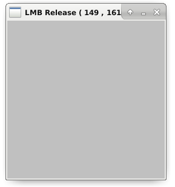

### 2. callback

Son funciones que son llamados cuando el valor de un widget se altera, un callback recibe de parametros un puntero tipo widget y otro tipo cualquier tipo, existen varios tipos de funciones callback, tienen la form siguiente

```r
void xyz_callback(Fl_Widget *w, void *data) {
...
}
```

El metodo callback((Fl_Widget *w, void* data), puede recibir dos punteros, una funcion y un dato cualquiera y este los llamada cuando el value del widget cambia, este sera el metodo por el cual se usara para el manejo de eventos en la calculadora

## Algoritmo infix to postfix

1. Se inicia la pila
2. Se escanea de izquierda a derecha la expresion infix
3. Si el caracter escaneado es un operando, se coloca en la salida postfix y si es un operador y la pila esta vacia o contiene el simbolo ‘(’ o ‘)’, se hace un push al operador en la pila.
4. Si el operador escaneado tiene mayor nivel de procedencia que el que el operador que se encuentra en la pila o si la pila esta vacia, se coloca en la pila
5. Si el operador escaneado tiene menor nivel de procedencia que el operador existente en la pila, se haca un pop all a todos los operadores, despues se hace un push al operador escaneado en la pila
6. Si el caracter escaneado es un ‘(’, se hace un push a el en la pila
7. Si el caracter escaneado es un ‘)’, se hace un pop en la pila hasta llegar a un ‘(’ y se coloca en la expresion postfix y se elimina ambos caracteres ‘(’ y ‘)’
8. Repetir todos los pasos desde 2 a 8 hasta que la expresion inflix sea escaneado o vacia
9. Se imprime la salida de la pila
10. Se hace un pop y salia de todos los caracteres, incluyendo al operador, de la pila hasta que no este vacia

| Label No. | Symbol Scanned | Stack | Expression |
| --- | --- | --- | --- |
| 1 | ( | ( |  |
| 2 | ( | (( |  |
| 3 | A | (( | A |
| 4 | * | ((* | A |
| 5 | ( | ((*( | A |
| 6 | B | ((*( | AB |
| 7 | + | ((*(+ | AB |
| 8 | D | ((*(+ | ABD |
| 9 | ) | ((* | ABD+ |
| 10 | / | ((*/ | ABD+ |
| 11 | E | ((*/ | ABD+E |
| 12 | ) | ( | ABD+E/* |
| 13 | - | (- | ABD+E/* |
| 14 | ( | (-( | ABD+E/* |
| 15 | F | (-( | ABD+E/*F |
| 16 | * | (-(* | ABD+E/*F |
| 17 | ( | (-(* ( | ABD+E/*F |
| 18 | G | (-(* ( | ABD+E/*FG |
| 19 | + | (-(* (+ | ABD+E/*FG |
| 20 | H | (-(* (+ | ABD+E/*FGH |
| 21 | / | (-(* (+/ | ABD+E/*FGH |
| 22 | K | (-(* (+/ | ABD+E/*FGHK |
| 23 | ) | (-(* | ABD+E/*FGHK/+ |
| 24 | ) | (- | ABD+E/* FGHK/+* |
| 25 | ) |  | ABD+E/* FGHK/+*- |

## Estructura del codigo para la calculadora

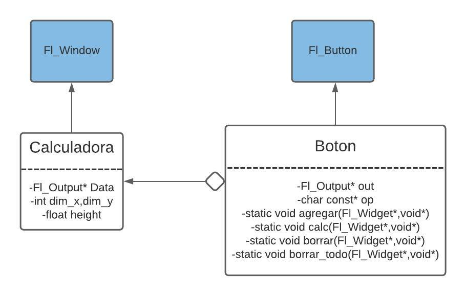

Figura1: Ilustracion de la estructura del proyecto

[figure not shown]

Figura2: Posibles mejoras al proyecto en la parte de boton

## Codigo Fuente

### Calculadora.h

```r
#ifndef CALCULADORA_H
#define CALCULADORA_H
#include "Boton.h"
#include <list>
class Calculadora: public Fl_Window
{
private:
    Fl_Output* Data; //Salida de codigo
    int dim_x,dim_y; //Dimensiones de los botones
    int height; //size del boton
public:
    Calculadora(int , int );
};

#endif // CALCULADORA_H
}
```

### Boton.h

```r
#ifndef BOTON_H
#define BOTON_H
/////////////////////////////
#include <FL/Fl_Window.H>
#include <FL/Fl.H>
#include <FL/Fl_Button.H>
#include <FL/Fl_Output.H>
/////////////////////////////
#include <string>
#include <stack>
#include <queue>
#include <map>
/////////////////////////////
#include "enum_base.h"
#include "aritmetic_base.h"
#include "expsymbol.h"
#include "infix2postfix.h"
#include "postfixEval.h"
#include "aritmetic_expression_eval.h"
#include "d_except.h"
/////////////////////////////
#include <iostream>
#include <stdio.h>
#include <sstream> //Biblioteca para convertir float->string
using namespace std;
class Boton: public Fl_Button
{
private:
    Fl_Output* out; //Salida de datos
    char const* op = ""; //Simbolo de cada boton
    //Metodos para botones especificos
    static void agregar(Fl_Widget*,void*);
    static void calc(Fl_Widget*,void*);
    static void borrar(Fl_Widget*,void*);
    static void borrar_todo(Fl_Widget*,void*);
public:
    Boton(int x,int y, int width, int height,char const* c,Fl_Output* display,int i =0); //constructor
};

#endif // BOTON_H
```

### Calculadora.cpp

```r
#include "Calculadora.h"
//Funcion para crear botones predeterminados
void crear_boton(int ancho, int largo,int fila,float height, int column, std::list<char const*>::iterator& ite,Fl_Output* Display)
{
    std::list<char const*> numeros = {"0","1","2","3","4","5","6","7","8","9"};
    bool num = false;
    std::list<char const*>::iterator first,last;
    first = numeros.begin();
    last = numeros.end();
    while (first!=last)
    {
        if(*first==*ite) num = true;
        first++;
    }
    if(*ite == "C") new Boton(1+fila*ancho,height/1.2-column*largo,ancho,largo,*ite,Display,3);
    else if(*ite == "DEL") new Boton(1+fila*ancho,height/1.2-column*largo,ancho,largo,*ite,Display,2);
    else if (*ite =="=") new Boton(1+fila*ancho,height/1.2-column*largo,ancho,largo,*ite,Display,1);
    else if(num) new Boton(1+fila*ancho,height/1.2-column*largo,ancho,largo,*ite,Display,4);
    else new Boton(1+fila*ancho,height/1.2-column*largo,ancho,largo,*ite,Display);
    ite++;
}
Calculadora::Calculadora(int width, int height_):Fl_Window(width, height_, ""),height(height_)
{
    label("Calculadora");
    Fl_Output* Data = new Fl_Output(20,20,360,70);
    Data->textsize(25);
    Data->value("");
    std::list<char const*>  simb = {"0",".","(",")","=","1","2","3","+","-","4","5","6","*","/","7","8","9","C","DEL","sen","cos","tan","^","log","exp","ln"};
    std::list<char const*>::iterator first = simb.begin();
    dim_x = 80;
    dim_y =60;
    int n=0,m=0;//n es columna y m es fila
    for (int i=0;i<simb.size();i++)
    {
        crear_boton(dim_x,dim_y,n,height,m,first,Data);
        n++;
        if (n>4) n=0,m++;// cada vez que termina una fila de llenarse, se sigue la siguiente fila y se reiniciar n
    }
    show();
}
```

### Boton.cpp

```r
#include "Boton.h"
using namespace std;
int estado = 0;
Boton::Boton(int x,int y, int width, int height,char const* c,Fl_Output* display,int i):Fl_Button(x,y,width,height,c)
{
    out = display;
    op = c;
    labelsize(25);
    switch(i)
    {
    case 1:
        callback(calc,(void*)out);
        break;
    case 2:
        callback(borrar,(void*)out);
        break;
    case 3:
        callback(borrar_todo,(void*)out);
        break;
    case 4:
        color(FL_WHITE);
        callback(agregar,(void*)out);
        break;
    default:
        callback(agregar,(void*)out);
    };
}
void Boton::agregar(Fl_Widget* w, void* c)
{
    Fl_Button* B = (Fl_Button*)w;
    Fl_Output* D = (Fl_Output*)c;
    if(estado==1) D->value("");
    estado =0;
    D->textcolor(FL_BLACK);
    cout << B->label() << endl;
    char const* e;
    string a = B->label();
    string b = D->value()+a;
    e = b.c_str();
    D->value(e);
}
void Boton::calc(Fl_Widget* w, void* c)
{
    Fl_Button* B = (Fl_Button*)w;
    Fl_Output* D = (Fl_Output*)c;
    if(estado==1)
    {
        D->value("");
        estado = 0;
        D->textcolor(FL_BLACK);
    }
    else if (estado==0)
    {
        _aritmetic_expression_eval expression;
        string infixExp = D->value();
        string sust_default = "(0-1)*";
        string sust_default2 = "(0+1)*";
        int tam = infixExp.size();
        for(int i=0;i<tam;i++)
        {
            if(i==0 & infixExp[i]=='+') infixExp.replace(i,1,sust_default2);
            else if(infixExp[i]=='-')
            {
                cout << "Se detecto un numero negativo empezando"<< endl;
                if (i==0)
                {
                    infixExp.replace(i,1,sust_default);
                    i+=sust_default.size();
                    tam+=i-1;
                }
                else if (i!=0 & (infixExp[i-1]=='(' | infixExp[i+1]=='t' | infixExp[i+1]=='e' |infixExp[i+1]=='c'|infixExp[i+1]=='s'|infixExp[i+1]=='l'|infixExp[i-1]=='*'|infixExp[i-1]== '/'|infixExp[i-1]=='^'))
                {
                    if (infixExp[i-1]!='('&infixExp[i-1]!='*'&infixExp[i-1]!='/'&infixExp[i-1]!='^')
                    {
                        infixExp.replace(i,1,"+" + sust_default);
                        i+=sust_default.size()+1;
                        tam+=i-2;
                    }
                    else
                    {
                        infixExp.replace(i,1,sust_default);
                        i+=sust_default.size();
                        tam+=i-1;
                    }
                }
                cout << "Expresion infix modificado "<< infixExp << endl;
            }
        }
        try
        {
            // convert to postfix
            expression.setInfixExp(infixExp);
            if (!expression.makepostfix())
            throw expressionError("infix2Postfix: Invalid expression");
            float resultado = expression.evaluate();
            cout << "Value of the expression = " << resultado << endl << endl;
            ostringstream ss;
            ss << resultado;
            D->value(ss.str().c_str());
        }
        // catch an exception and output the error
        catch (const expressionError& ee)
        {
            cout << ee.what() << endl << endl;
            D->value(ee.what().c_str());
            D->textcolor(FL_RED);
            estado  = 1;
        }
    }
}
void Boton::borrar(Fl_Widget* w, void* c)
{
    Fl_Button* B = (Fl_Button*)w;
    Fl_Output* D = (Fl_Output*)c;
    D->textcolor(FL_BLACK);
    cout << B->label() << endl;
    char const* e;
    string a = D->value();
    if (a=="") return;
    string b ="";
    a.replace(a.size()-1,1,b);
    e = a.c_str();
    D->value(e);
}
void Boton::borrar_todo(Fl_Widget* w, void* c)
{
    Fl_Button* B = (Fl_Button*)w;
    Fl_Output* D = (Fl_Output*)c;
    D->textcolor(FL_BLACK);
    cout << B->label() << endl;
    char const* e= "";
    D->value(e);

}
```

### main.cpp

```r
#include "Calculadora.h"
using namespace std;

int main (int argc, char ** argv)
{
    Calculadora _Calc(400,500);
    return(Fl::run());
}
```

#### Output del main.cpp

[figure not shown]

Figura3: Salida de consola e main.cpp

## Conclusiones

Se logro un mejor manejo de las biblioteclas FLTK y del lenguaje C++, tambien de lo importante que es hacer codigo limpio y tener los archivos del proyecto organizados, ademas de dar uso al algoritmo infix postfix.

## Bibliografia

Javapoint, Program to convert infix to postfix expression in C++ using the Stack Data Structure, recuperado de https://www.javatpoint.com/program-to-convert-infix-to-postfix-expression-in-cpp-using-the-stack-data-structure

Spitzak B., FLTK 1.3.5 Programming Manual, recuperado de https://www.fltk.org/doc-1.3/fltk.pdf

Pingel M., 559 HANDS-ON TUTORIAL:INTRODUCTION TO FLTK, recuperado de http://pages.cs.wisc.edu/~pingelm/handson.html